# Libraries

### LGBM - Residual

```python
residual = y_test-y_pred
```

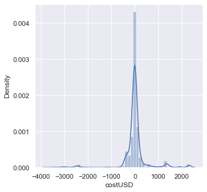

```python
sns.distplot(residual)
```

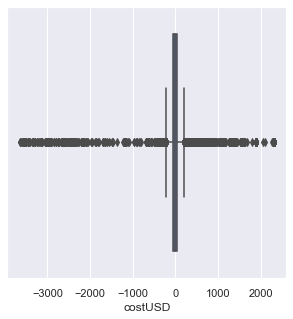

```python
sns.boxplot(residual)
```

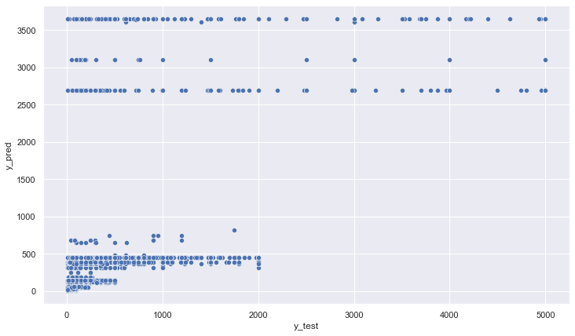

```python
plt.figure(figsize = ( 12, 7))
_ = sns.scatterplot(y=y_pred,x= y_test)
_ = plt.xlabel('y_test')
_ = plt.ylabel('y_pred')
```

```python
X_test_df = X_test
```

```python
X_test_df['y_test']=y_test
X_test_df['y_pred']=y_pred
```

```python
X_test_df['result'] = X_test_df['y_pred'] - X_test_df['y_test']
```

```python
X_test_df['result'].sum()
```

```
30865.68092295495
```

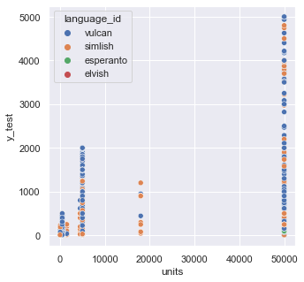

```python
sns.scatterplot(data = X_test_df,y=X_test_df['y_test'],x=X_test_df['units'],hue='language_id')
```

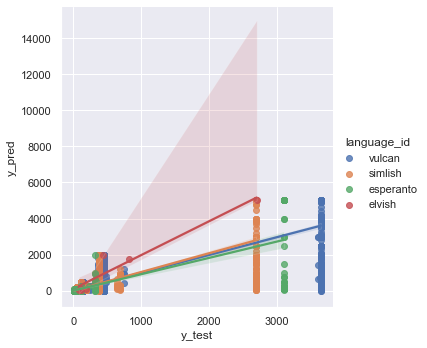

```python
plt.figure(figsize = ( 12, 7))
_ = sns.lmplot(data=X_test_df,y='y_test',x= 'y_pred',hue='language_id')
_ = plt.xlabel('y_test')
_ = plt.ylabel('y_pred')
```

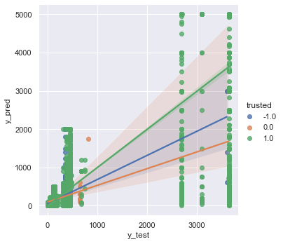

```python
plt.figure(figsize = ( 12, 7))
_ = sns.lmplot(data=X_test_df,y='y_test',x= 'y_pred',hue='trusted')
_ = plt.xlabel('y_test')
_ = plt.ylabel('y_pred')
```

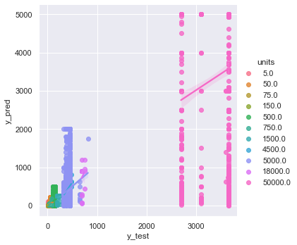

```python
plt.figure(figsize = ( 12, 7))
_ = sns.lmplot(data=X_test_df,y='y_test',x= 'y_pred',hue='units')
_ = plt.xlabel('y_test')
_ = plt.ylabel('y_pred')
```

```python
r2_score(y_test,y_pred)
```

```
0.652898689059617
```

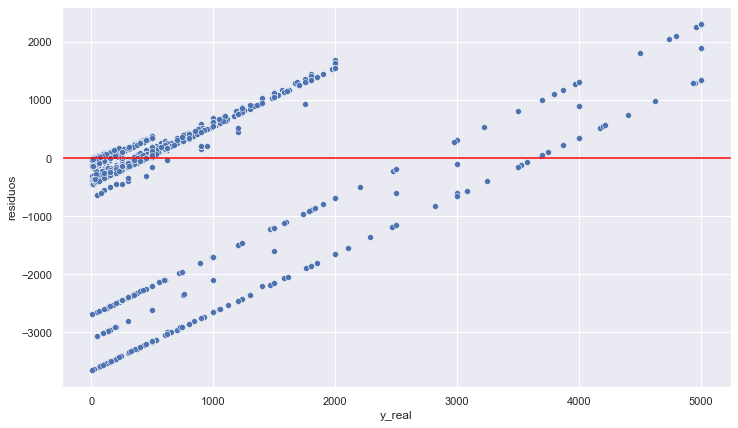

```python
plt.figure( figsize = ( 12, 7))
_ = sns.scatterplot(y=residual,x= y_test)
_ = plt.xlabel('y_real')
_ = plt.ylabel('residuos')
_ = plt.axhline(0,color='red')

plt.show()
```

### Table - Predicting

A table with the suggested prices for projects of 30, 75, 150 and 500 words in all of the languages present in the dataset.

```python
prices = pd.DataFrame({'units':[30, 75,150,500,30, 75, 150,500,30, 75, 150,500,30, 75, 150,500],
              'language_id':['vulcan','vulcan','vulcan','vulcan', 'simlish', 'simlish', 'simlish', 'simlish', 'esperanto', 'esperanto', 'esperanto', 'esperanto', 'elvish', 'elvish', 'elvish', 'elvish'],
              'trusted':[1,1,1,1,1,1,1,1,1,1,1,1,1,1,1,1]})
```

```python
prices['pred_price'] = lgbm.predict(prices,random_state=42)
```

```python
prices['pred_price_bunny'] = prices['pred_price']*1.15
```

```python
prices.sort_values('units')
```

|  | units | language_id | trusted | pred_price | pred_price_bunny |
| --- | --- | --- | --- | --- | --- |
| 0 | 30 | vulcan | 1 | 55.987610 | 64.385751 |
| 4 | 30 | simlish | 1 | 51.363793 | 59.068362 |
| 8 | 30 | esperanto | 1 | 39.729608 | 45.689050 |
| 12 | 30 | elvish | 1 | 114.693545 | 131.897577 |
| 1 | 75 | vulcan | 1 | 10.675268 | 12.276558 |
| 5 | 75 | simlish | 1 | 10.558871 | 12.142702 |
| 9 | 75 | esperanto | 1 | 9.762895 | 11.227329 |
| 13 | 75 | elvish | 1 | 73.790175 | 84.858701 |
| 2 | 150 | vulcan | 1 | 18.106784 | 20.822801 |
| 6 | 150 | simlish | 1 | 16.011847 | 18.413624 |
| 10 | 150 | esperanto | 1 | 16.418671 | 18.881471 |
| 14 | 150 | elvish | 1 | 81.188294 | 93.366538 |
| 3 | 500 | vulcan | 1 | 146.460112 | 168.429129 |
| 7 | 500 | simlish | 1 | 119.864268 | 137.843909 |
| 11 | 500 | esperanto | 1 | 109.424356 | 125.838010 |
| 15 | 500 | elvish | 1 | 183.434848 | 210.950075 |

```python
prices.to_csv('predicted_table.csv',index=False)
```

## Model : Predict Time from Units

This model won't be used in the solution but could be considered if time variables had a high influence on pricing. Used to understand how good time explains units.

```python
X = df3['units'].to_list()
```

```python
X = np.array(df3['units'].to_list())
y = np.array(df3['time'].to_list())

X_train, X_test, y_train, y_test = train_test_split(X, y, test_size=0.3, random_state=42)
```

```python
candidate_models = {'Tree':DecisionTreeRegressor(max_depth=20),
                      'RandomForest':RandomForestRegressor(max_depth=20),
                      'LGBM':LGBMRegressor(max_depth=20),
                      'KNeighborsRegressor':KNeighborsRegressor()
                     }
```

```python
avaliacao = {}
for nome,model in candidate_models.items():
    # Avalia a crossvalidação
    score = cross_val_score(model, # "Model" full pipe + model
                            X_train.reshape(-1, 1) , y_train.reshape(-1, 1), # Nossos dados, excluindo o teste
                            cv=5, # Validação cruzada temporal
                            scoring='neg_mean_absolute_error', # Usando a métrica MAE
                           n_jobs=-1 # Número de processadores, para ser mais rápido
                           ) # Tirando a média de todos os folds
    avaliacao[f'{nome} avg'] = -score.mean()
    avaliacao[f'{nome} median'] = np.median(-score)# -score e não score para tornar o número positivo
```

```python
avaliacao
```

```
{'Tree avg': 299.62550951510667,
 'Tree median': 299.96906580409984,
 'RandomForest avg': 299.59152858152754,
 'RandomForest median': 300.412319147924,
 'LGBM avg': 299.6773766237765,
 'LGBM median': 300.0212385951799,
 'KNeighborsRegressor avg': 299.8344165621079,
 'KNeighborsRegressor median': 315.29752195734005}
```

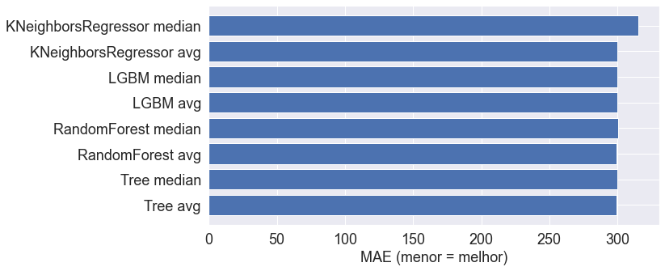

```python
plt.figure(figsize=(10,5))
plt.barh(*zip(*avaliacao.items()))
plt.xticks(fontsize=18)
plt.yticks(fontsize=18)
plt.xlabel('MAE (menor = melhor)',size=18)
plt.show()
```

```python
avaliacao
```

```
{'Tree avg': 299.62550951510667,
 'Tree median': 299.96906580409984,
 'RandomForest avg': 299.59152858152754,
 'RandomForest median': 300.412319147924,
 'LGBM avg': 299.6773766237765,
 'LGBM median': 300.0212385951799,
 'KNeighborsRegressor avg': 299.8344165621079,
 'KNeighborsRegressor median': 315.29752195734005}
```

```python
residual = y_pred - np.array(y_test)
```

# Assignment 1

It was created a model for pricing voice-over using our current data from Pros prices. Looking for pricing today the user will type how many units he needs for the job. We know that not just the amount of words is important for the final price, but how trustable the Pros are, which language the job should be done fewer available languages could have a higher price. To follow thoose complexion boundaries it was used a non-Linear Regression Model.

Despite that, the model is reflecting real data and it's important to answer: are we expecting non-Linear pricing? Example 75 words costing lower than 30. Should we see linear pricing, where more words always reflects more money, or not always? But of course that after discussing that, the model will give in hand, helping us pricing taking into account: language and trust, and will possible pricing differently for each case. Now, the user input the language, units(words), desirable trust and the model return recommended value in Dolar, before the return value we increase the predicted price by 15%.

# Assignment 2

First of all, it's important to understand which kind of features are relevant for thoose that create a love letter (Pros). Knowing that we can understand if we do not have any data. This is important too in the medium-term we collect the right relevant data and create a good model for pricing love letters.

Once we know which are relevant features for a love letter we can together with the business, understand if one of our subcategories today is close to the important features identified, for example, a candidate for it is inside the written content, already working today. If yes, we can test the model using some suggested prices for Pros ( We can sample and collect some of thoose ).

In general, we must create a baseline pricing, from research, benchmarking, and interviewing potential Pros for love letters, this will give us some information and we can decide to start from an existing model or create a model from zero, collecting some data by web scraping, research for example.